# Marco Wittmans Patch Foraging Task: Leave - Stay Decision

## Reward Rate Curves & Reward Magnitudes

See [paper](https://www.nature.com/articles/ncomms12327)

And [supplementary material](https://static-content.springer.com/esm/art%3A10.1038%2Fncomms12327/MediaObjects/41467_2016_BFncomms12327_MOESM821_ESM.pdf)

### What hes done & why

So basically he has these reward rate (RR) curves based on foraging theory which I tried to find; it is something to do with Optimal foraging theory and some guy Holling and he has equations that are Type I,II & III; anyway; he provided curves & reward data so using those. But he also says- See Methods/Reward Sequences; that the RR curves we show were established empirically at the end of the iterative process he describes; so was probably a bit of a tough one to do as never had the original curves.

This notebook is to look at the RR curves and the reward magnitudes $R_{mag}$ he's provided; along with his stated methods to produce them- which is not compeltely clear; however: $$RR = \frac{R_{mag}}{N_{\Delta T}}$$ where $N_{\Delta T}$ is number of time steps since last reward or since start of trial.

```python
#imports
from scipy import io
import numpy as np
import plotly.graph_objects as go
from plotly.subplots import make_subplots
import matplotlib.pyplot as plt
import itertools
```

```python
#Loading Marco's struct: shld be decent pattern for reading .mat structs into python
marco = io.loadmat("./PatchCommand/wittmann2016_rawexp_04-Apr-2024.mat",squeeze_me = True);
marcoA = marco['rawexp'];
marcoA[1].dtype

#And defining his little function which is the same for each RR curve
def marcosRR(x, beta, midpoint, scale, updown):

    exp_beta_x = np.exp(beta * x)
    exp_beta_midpoint = np.exp(beta * midpoint)

    result = scale * (exp_beta_x / (exp_beta_x + exp_beta_midpoint)) + updown
    return result
```

```python
# getting the good bits from his struct; this is just so weird; the indexing, I don't really get it the size of arrays make no sense,item() what even is that.
# the data is correct though so fine.
rew2ld=[]
ldStay=[]
ldGo=[]

betas = []
midpoints = []
scales = []
updowns = []

for i in range(90):
    entry=marcoA[i]
    #newentry=np.array(entry['rew2ld']).item()
    rew2ld.append(np.array(entry['rew2ld']).item())
    #newentry=np.array(entry['ldGo']).item()
    ldStay.append(np.array(entry['ldstay']).item())
    ldGo.append(np.array(entry['ldgo']).item())


    funcParams=entry['fun'].item()
    betas.append(funcParams['beta'].item())
    midpoints.append(funcParams['midpoint'].item())
    scales.append(funcParams['scale'].item())
    updowns.append(funcParams['updown'].item())
```

## The Default Patch

No legend here; it's very messy; but the idea is clear

[figure not shown]

```python
plot_ldGo(ldGo)
```

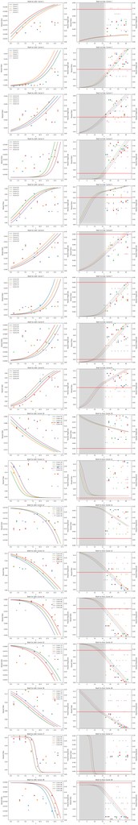

```python
plot_batches(rew2ld, ldStay, ldGo, betas, midpoints, updowns, scales)
```

```python
def plot_batches(rew2ld, ldStay, ldGo, betas, midpoints, updowns, scales, batch_size=5):

    num_batches = len(betas) // batch_size
    num_rows = num_batches
    marker_shapes = itertools.cycle(['o', 's', 'D', '^', 'v'])
    fig, axes = plt.subplots(num_rows, 2, figsize=(15, num_rows * 5), constrained_layout=True)
    max_rew2ld = max([max(rew) for rew in rew2ld])
    max_stay = max([max(rew) for rew in ldStay])

    for i in range(num_batches):
        row = i % num_rows
        axR2LD = axes[row, 0]
        axR2LD2 = axR2LD.twinx()

        axLD2END = axes[row, 1]
        axLD2END2 = axLD2END.twinx()

        plotted_midpoints = []
        batch_max_combined_y = []
        batch_min_combined_y = []
        for j in range(batch_size):
            idx = i * batch_size + j
            if midpoints[idx] in plotted_midpoints:
                if plotted_midpoints.count(midpoints[idx]) >= 2:
                    linestyle = ':'
                else:
                    linestyle = '--'
            else:
                linestyle = '-'
            plotted_midpoints.append(midpoints[idx])

            # REW2LD
            x = np.linspace(0, len(rew2ld[idx]),100)
            y = marcosRR(x, betas[idx], midpoints[idx], scales[idx], updowns[idx])

            #ax.plot(x, y, label=f'Curve {idx + 1}', linestyle=linestyle, linewidth='3.')
            color = axR2LD.plot(x, y, label=f'Curve {idx}', linestyle=linestyle, linewidth=2)[0].get_color()

            # Filter non-zero elements
            non_zero_indices = [k for k, val in enumerate(rew2ld[idx]) if val != 0]
            non_zero_values = [val for val in rew2ld[idx] if val != 0]

            axR2LD2.scatter(non_zero_indices, non_zero_values, marker=next(marker_shapes), color=color)

            # LDSTAY
            gradient = (y[-1] - y[-2]) / (x[-1] - x[-2])

            new_x = np.linspace(len(rew2ld[idx]),len(rew2ld[idx])+ len(ldStay[idx]),100)
            new_y = y[-1] + gradient * (new_x - new_x[0])

            combined_x = np.concatenate((x, new_x))
            combined_y = np.concatenate((y, new_y))
            batch_max_combined_y.append(np.max(combined_y))
            batch_min_combined_y.append(np.min(combined_y))
            fill_min_y = 0.045 if np.min(combined_y) > 0.05 else np.min(combined_y)



            axLD2END.plot(combined_x, combined_y, label=f'Curve {idx}', linestyle=linestyle, linewidth=1,color=color)
            axLD2END.fill_between(x, fill_min_y, max_rew2ld, where=(x <= len(rew2ld[idx])), color='lightgrey', alpha=0.3)

            non_zero_indices = [k+ len(rew2ld[idx]) for k, val in enumerate(ldStay[idx]) if val != 0]
            non_zero_values = [val for val in ldStay[idx] if val != 0]



            axLD2END2.scatter(non_zero_indices, non_zero_values, marker=next(marker_shapes), color=color)

            #LDGO
            axLD2END.axhline(y=0.05, color='r', linestyle='-')

            non_zero_indices = [k + len(rew2ld[idx]) for k, val in enumerate(ldGo[idx]) if val != 0]
            non_zero_values = [val for val in ldGo[idx] if val != 0]

            axLD2END2.scatter(non_zero_indices, non_zero_values, marker='+', color=color)



        axR2LD.set_title(f'Start to LSD: Curve {i+1}')
        axLD2END.set_title(f'Start to End: Curve {i+1}')
        axR2LD.set_xlabel('x')
        axR2LD.set_ylabel('Reward Rate')
        axR2LD2.set_ylabel('Reward Magnitude')

        axLD2END.set_xlabel('x')
        axLD2END.set_ylabel('Reward Rate')
        axLD2END2.set_ylabel('Reward Magnitude')


        axR2LD2.set_ylim(0, max_rew2ld)

        min_y = min(batch_min_combined_y)
        max_y = max(batch_max_combined_y)
        min_y = 0.045 if min_y > 0.05 else min_y
        max_y = 0.055 if max_y < 0.05 else max_y
        axLD2END.set_ylim(min_y, max_y)
        axLD2END2.set_ylim(0, max_stay)
        axR2LD.legend()
    plt.show()
```

```python
def plot_ldGo(ldGo):
    fig, ax = plt.subplots(figsize=(15, 10))
    ax2 = ax.twinx()  # Create secondary y-axis

    marker_shapes = itertools.cycle([ '1', '2','*', 'x', '+', '3', '4'])


    # Calculate the global max for rew2ld to set consistent y-axis limits
    max_ldGo = max([max(rew) for rew in ldGo if len(rew) > 0])

    # Plot the horizontal line at 0.5 on secondary y-axis
    ax.axhline(y=0.05, color='r', linestyle='-')

    for i in range(len(ldGo)):

        # Filter non-zero elements
        non_zero_indices = [k for k, val in enumerate(ldGo[i]) if val != 0]
        non_zero_values = [val for val in ldGo[i] if val != 0]

        # Plot the secondary axis points
        marker = next(marker_shapes)
        ax2.scatter(non_zero_indices, non_zero_values, label=f'Points {i+1}', marker=marker)

    ax.set_xlabel('x')
    ax.set_ylabel('RR- Default')
    ax2.set_ylabel('Reward Magnitude')
    ax2.set_ylim(0, max_ldGo+0.1)  # Set consistent y-axis limits for secondary axis

    plt.title("Default Patch: Curves & Reward Magnitude")
    plt.show()
```

```python
def plot_batches(rew2ld,betas, midpoints, updowns, scales, batch_size=5):
    num_batches = len(betas) // batch_size
    num_rows = (num_batches + 1) // 2
    marker_shapes = itertools.cycle(['o', 's', 'D', '^', 'v'])
    fig, axes = plt.subplots(num_rows, 2, figsize=(15, num_rows * 5), constrained_layout=True)
    max_rew2ld = max([max(rew) for rew in rew2ld])

    for i in range(num_batches):
        row = i % num_rows
        col = i // num_rows
        ax = axes[row, col]
        ax2 = ax.twinx()


        plotted_midpoints = []
        for j in range(batch_size):
            idx = i * batch_size + j
            if midpoints[idx] in plotted_midpoints:
                if plotted_midpoints.count(midpoints[idx]) >= 2:
                    linestyle = ':'
                else:
                    linestyle = '--'
            else:
                linestyle = '-'
            plotted_midpoints.append(midpoints[idx])


            x = np.linspace(0, len(rew2ld[idx]),100)
            y = marcosRR(x, betas[idx], midpoints[idx], scales[idx], updowns[idx])

            #ax.plot(x, y, label=f'Curve {idx + 1}', linestyle=linestyle, linewidth='3.')
            color = ax.plot(x, y, label=f'Curve {idx}', linestyle=linestyle, linewidth=3)[0].get_color()

            # Filter non-zero elements
            non_zero_indices = [k for k, val in enumerate(rew2ld[idx]) if val != 0]
            non_zero_values = [val for val in rew2ld[idx] if val != 0]

            ax2.scatter(non_zero_indices, non_zero_values, marker=next(marker_shapes), color=color)
        ax.set_title(f'Start to LSD: Curve {i+1}')
        ax.set_xlabel('x')
        ax.set_ylabel('Reward Rate')
        ax2.set_ylabel('Reward Magnitude')
        ax2.set_ylim(0, max_rew2ld)
        ax.legend()
    plt.show()

plot_batches(rew2ld, betas, midpoints, updowns, scales)
```

[output not shown]